# IODS course project

Marianne Holopainen

# Introduction to Open Data Science - Course Project

# About the project

I heard about the course from Sisu and from the mailing list of dbhubstudents. I am now excited to learn more about the Rstudio, GitHub and coding.

The R for Health Data Science book (chapters 1-4) were easy to read and some parts also easy to understand. Most difficult was to follow how to operate with different functions, but practical exercises will probably give me more understanding how basic functions will work. I do not have the favorite topic yet but all information was valid. Overall, reading the book chapter was a good warm-up for the course, I think.

```r
# This is a so-called "R chunk" where you can write R code.

date()
```

```
## [1] "Mon Dec 12 12:32:58 2022"
```

```r
#install.packages("rmarkdown").
```

Link to my GitHub: https://github.com/mariholo/IODS-project.

# Assignment 2

This week I have worked with Data wrangling exercises as well as data analyses of linear regression. I have learnt basics of summarization and plotting data, as well as the linear regression analysis.

The work of the week are presented next.

```r
date()
```

```
## [1] "Mon Dec 12 12:32:58 2022"
```

```r
#2.0
#data wrangling in R script:

#Marianne Holopainen, 7.11.2022, exercise 2. SEE THESE IN create_learning2014.R

#reading the JYTOPKYS3.data into R.

#library(tidyverse) # install.packages("tidyverse")
#JYTOPKYS3_data <- read.delim("~/IODS-project/data/JYTOPKYS3-data.txt")
  #stringsAsFactors = FALSE
  #View(JYTOPKYS3_data)

#Create an analysis dataset with the variables gender, age, attitude,
#deep, stra, surf and points.
#Scale all combination variables to the original scales (by taking the mean).
#Exclude observations where the exam points variable is zero.
#(The data should then have 166 observations and 7 variables)

#Deep     Deep approach             ~d_sm+d_ri+d_ue
#Surf     Surface approach          ~su_lp+su_um+su_sb
#Stra     Strategic approach        ~st_os+st_tm
#Points   Yhteispisteet (max kaikista)'

#VAR d_sm:1=D03+D11+D19+D27 #seaking meaning.
#+VAR d_ri:1=D07+D14+D22+D30 #relating ideas.
#+VAR d_ue:1=D06+D15+D23+D31 #use of evidence.
#+VAR su_lp:1=SU02+SU10+SU18+SU26 #lack of purpose.
#+VAR su_um:1=SU05+SU13+SU21+SU29 #unrelated memorising.
#+VAR su_sb:1=SU08+SU16+SU24+SU32 #syllabus-boundeness.
#+VAR st_os:1=ST01+ST09+ST17+ST25 #organized studying.
#+VAR st_tm:1=ST04+ST12+ST20+ST28 #time management.
#+VAR Deep:1=d_sm+d_ri+d_ue #deep approach.
#+VAR Surf:1=su_lp+su_um+su_sb #surface approach.
#+VAR Stra:1=st_os+st_tm #strategic approach.

#deep, surf, stra and their means.
#attach(JYTOPKYS3_data)
#  JYTOPKYS3_data$deep <- (D03+D11+D19+D27+D07+D14+D22+D30+D06+D15+D23+D31)/12
#JYTOPKYS3_data$surf <- (SU02+SU10+SU18+SU26+SU05+SU13+SU21+SU29+SU08+SU16+SU24+SU32)/12
#JYTOPKYS3_data$stra <- (ST01+ST09+ST17+ST25+ST04+ST12+ST20+ST28)/8
#detach(JYTOPKYS3_data)

#exercise_data2 <- JYTOPKYS3_data[c(57:63)]#choose the correct outcomes.

#attach(exercise_data2)#lopullinen data tehtavaan.
#exercise_data_final <- exercise_data2[ which(Points > 0),]#exludes 0 values.
#detach(exercise_data2)

#View(exercise_data_final)

#Use `str()` and `head()` to make sure that the structure of the data is correct?
#write_csv(exercise_data_final, "learning2014.csv")
#read_csv("learning2014.csv")
```

## 2.1. The structure and the dimensions of the data

The outcomes of deep, stra and surf depict deep, surface, and strategic approach of study skills from the measure of Approaches and Study Skills Inventory for Students. Deep-outcome is composed by summing 12 questions, that ask about “seeking meaning”, “relating ideas”, and “use of evidence”, and then divided by the number of the items of the scale (range: 1-5). Surf-outcome is composed by summing 12 questions, that ask about “lack of purpose”, “unrelated memorising”, and “syllabus-boundeness”, and then divided by the number of the items of the scale (range: 1-5). In addition, Stra-outcome includes the mean of 8 items, that measure “organized studying” and “time management”. Lastly, there are Points-outcome that includes the total score from all the questions.

```r
#1, explore the sturucture and dimensions of the data.
library(tidyverse) # install.packages("tidyverse")
learning2014.data <- read.csv("~/IODS-project/data/learning2014-data.txt")
stringsAsFactors = FALSE
View(learning2014.data)

#N = gender
learning2014.data %>%
  count(gender, sort = TRUE)
```

```
##   gender   n
## 1      F 110
## 2      M  56
```

```r
#N =age
learning2014.data %>%
  count(age, sort = TRUE)
```

```
##    age  n
## 1   21 31
## 2   20 25
## 3   22 20
## 4   23 12
## 5   25 10
## 6   19  7
## 7   24  7
## 8   26  6
## 9   30  5
## 10  29  4
## 11  37  4
## 12  18  3
## 13  27  3
## 14  31  3
```

[output cut: 17 more lines]

```r
library(tidyverse)
library(gapminder) # dataset
library(finalfit)
library(broom)
library(ggplot2)

#statistics.
glimpse(learning2014.data)
```

```
## Rows: 166
## Columns: 7
## $ gender   <chr> "F", "M", "F", "M", "M", "F", "M", "F", "M", "F", "M", "F", "…
## $ age      <int> 53, 55, 49, 53, 49, 38, 50, 37, 37, 42, 37, 34, 34, 34, 35, 3…
## $ attitude <dbl> 3.7, 3.1, 2.5, 3.5, 3.7, 3.8, 3.5, 2.9, 3.8, 2.1, 3.9, 3.8, 2…
## $ deep     <dbl> 3.583333, 2.916667, 3.500000, 3.500000, 3.666667, 4.750000, 3…
## $ stra     <dbl> 3.375, 2.750, 3.625, 3.125, 3.625, 3.625, 2.250, 4.000, 4.250…
## $ surf     <dbl> 2.583333, 3.166667, 2.250000, 2.250000, 2.833333, 2.416667, 1…
## $ points   <int> 25, 12, 24, 10, 22, 21, 21, 31, 24, 26, 31, 31, 23, 25, 21, 3…
```

```r
ff_glimpse(learning2014.data)
```

```
## $Continuous
##             label var_type   n missing_n missing_percent mean  sd  min
## age           age    <int> 166         0             0.0 25.5 7.8 17.0
## attitude attitude    <dbl> 166         0             0.0  3.1 0.7  1.4
## deep         deep    <dbl> 166         0             0.0  3.7 0.6  1.6
## stra         stra    <dbl> 166         0             0.0  3.1 0.8  1.2
## surf         surf    <dbl> 166         0             0.0  2.8 0.5  1.6
## points     points    <int> 166         0             0.0 22.7 5.9  7.0
##          quartile_25 median quartile_75  max
## age             21.0   22.0        27.0 55.0
## attitude         2.6    3.2         3.7  5.0
## deep             3.3    3.7         4.1  4.9
## stra             2.6    3.2         3.6  5.0
## surf             2.4    2.8         3.2  4.3
## points          19.0   23.0        27.8 33.0
##
## $Categorical
##         label var_type   n missing_n missing_percent levels_n levels
## gender gender    <chr> 166         0             0.0        2      -
##        levels_count levels_percent
## gender            -              -
```

## 2.2. A graphical overview of the data and summaries of the variables in the data

Summary of statistics for the outcomes are presented in Table following:

```r
ff_glimpse(learning2014.data)
```

```
## $Continuous
##             label var_type   n missing_n missing_percent mean  sd  min
## age           age    <int> 166         0             0.0 25.5 7.8 17.0
## attitude attitude    <dbl> 166         0             0.0  3.1 0.7  1.4
## deep         deep    <dbl> 166         0             0.0  3.7 0.6  1.6
## stra         stra    <dbl> 166         0             0.0  3.1 0.8  1.2
## surf         surf    <dbl> 166         0             0.0  2.8 0.5  1.6
## points     points    <int> 166         0             0.0 22.7 5.9  7.0
##          quartile_25 median quartile_75  max
## age             21.0   22.0        27.0 55.0
## attitude         2.6    3.2         3.7  5.0
## deep             3.3    3.7         4.1  4.9
## stra             2.6    3.2         3.6  5.0
## surf             2.4    2.8         3.2  4.3
## points          19.0   23.0        27.8 33.0
##
## $Categorical
##         label var_type   n missing_n missing_percent levels_n levels
## gender gender    <chr> 166         0             0.0        2      -
##        levels_count levels_percent
## gender            -              -
```

Means by gender are presented here:

```r
#create data frame for Means
df <- data.frame(gender = c('female', 'male'),
                 Points = c(22.3, 23.5),
                 Stra = c(3.20, 2.96),
                 Deep = c(3.66, 3.72),
                 Surf = c(2.83, 2.70))

#view data frame
df
```

```
##   gender Points Stra Deep Surf
## 1 female   22.3 3.20 3.66 2.83
## 2   male   23.5 2.96 3.72 2.70
```

Females have lower total scores than males. On average, females used also more strategic and surface approach of study skills and male used more deep approach.

Boxplots present the means by gender here:

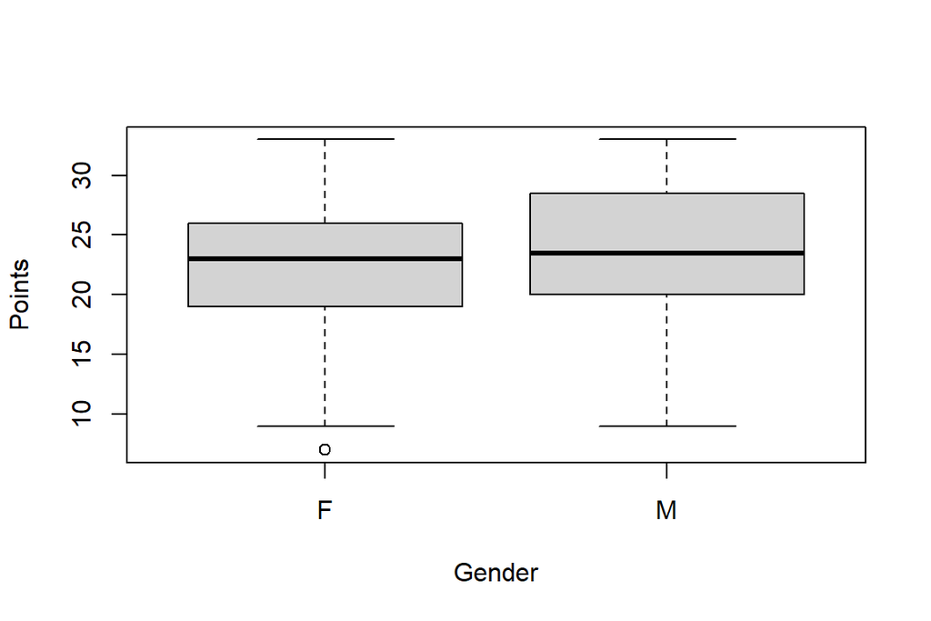

```r
boxplot(learning2014.data$points ~ learning2014.data$gender,
xlab = "Gender",
ylab = "Points")
```

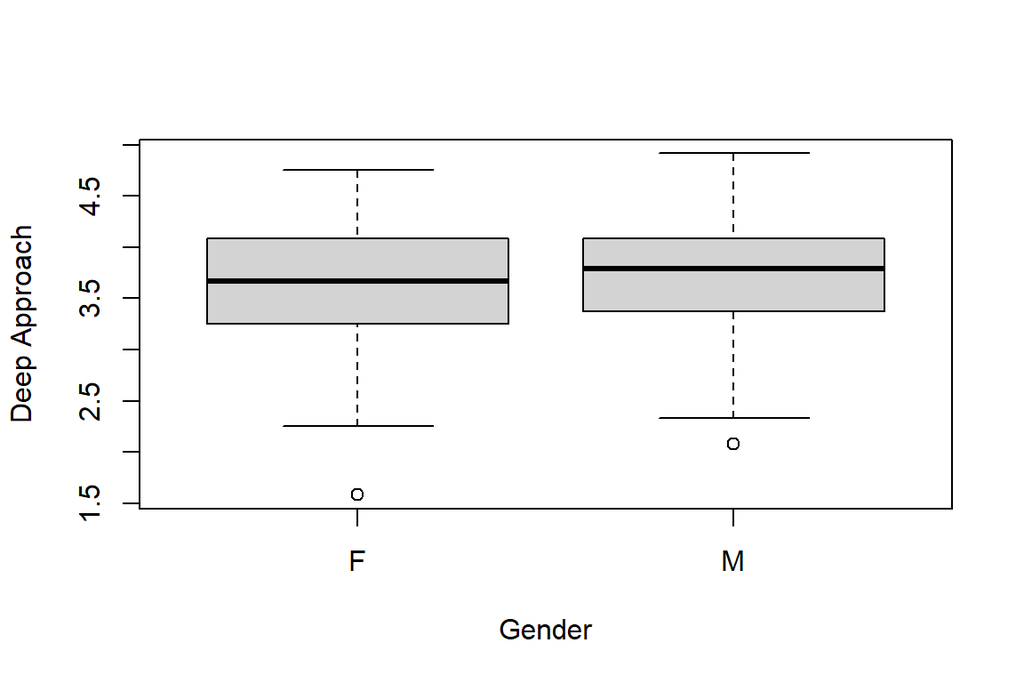

```r
boxplot(learning2014.data$deep ~ learning2014.data$gender,
xlab = "Gender",
ylab = "Deep Approach")
```

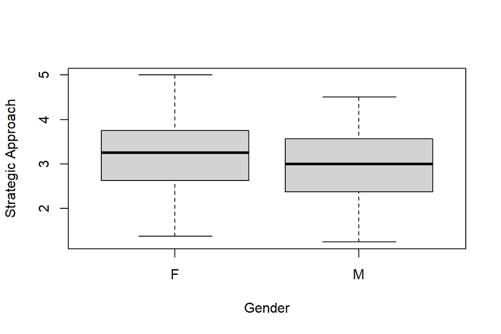

```r
boxplot(learning2014.data$stra ~ learning2014.data$gender,
xlab = "Gender",
ylab = "Strategic Approach")
```

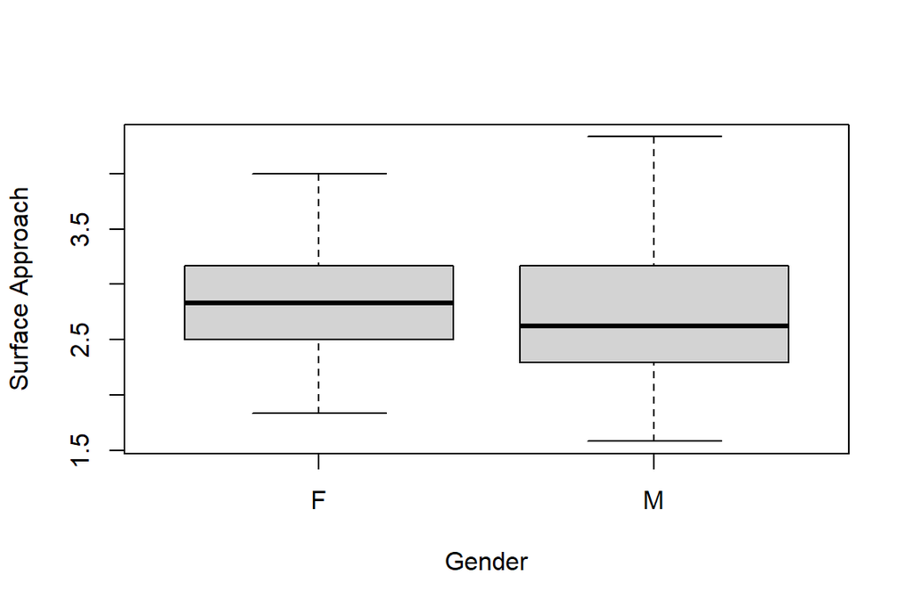

```r
boxplot(learning2014.data$surf ~ learning2014.data$gender,
xlab = "Gender",
ylab = "Surface Approach")
```

and histograms for the outcomes are displayed here for the total sample:

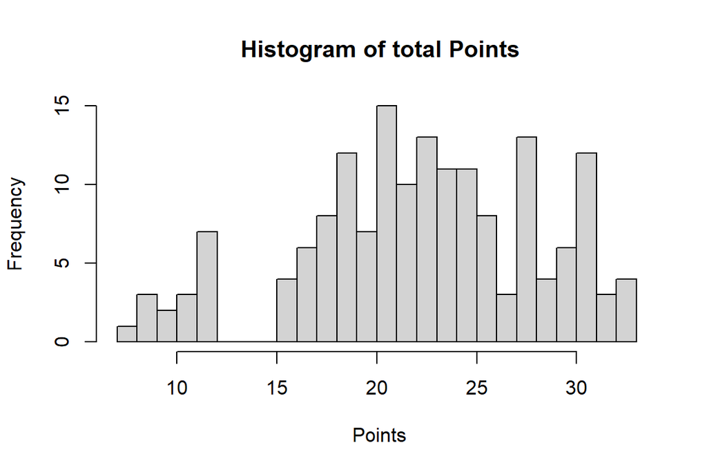

```r
hist(learning2014.data$points,
breaks = 20,
xlab = " Points",
main = " Histogram of total Points")
```

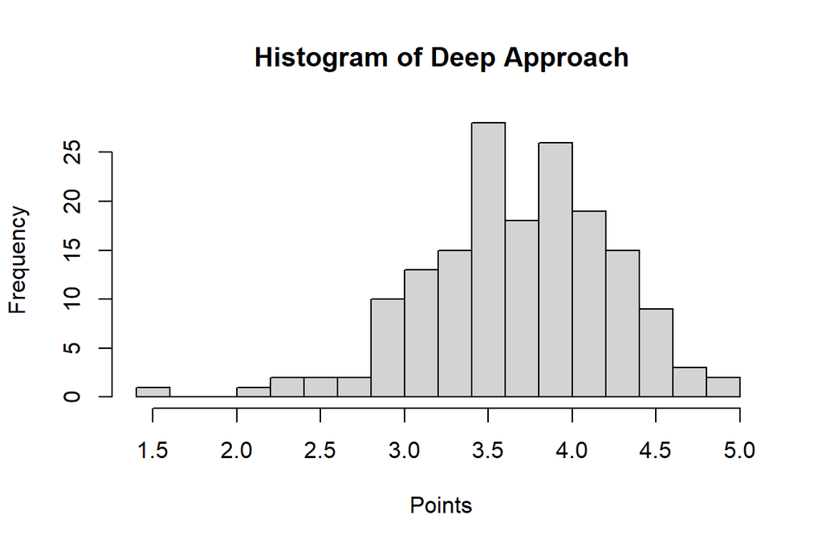

```r
hist(learning2014.data$deep,
breaks = 20,
xlab = " Points",
main = " Histogram of Deep Approach")
```

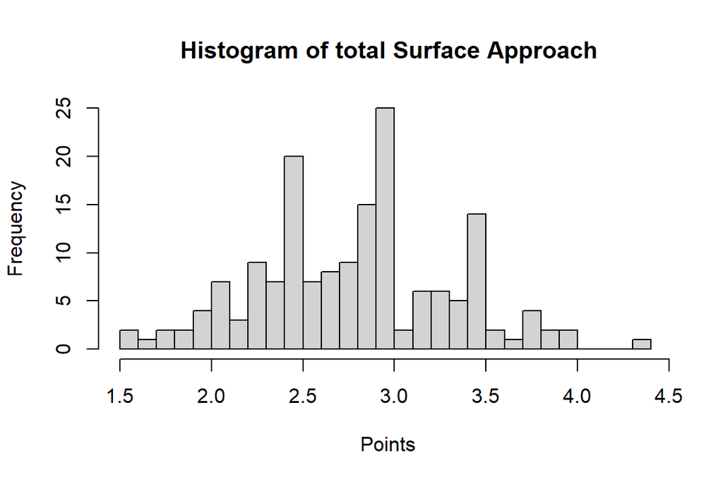

```r
hist(learning2014.data$surf,
breaks = 20,
xlab = " Points",
main = " Histogram of total Surface Approach")
```

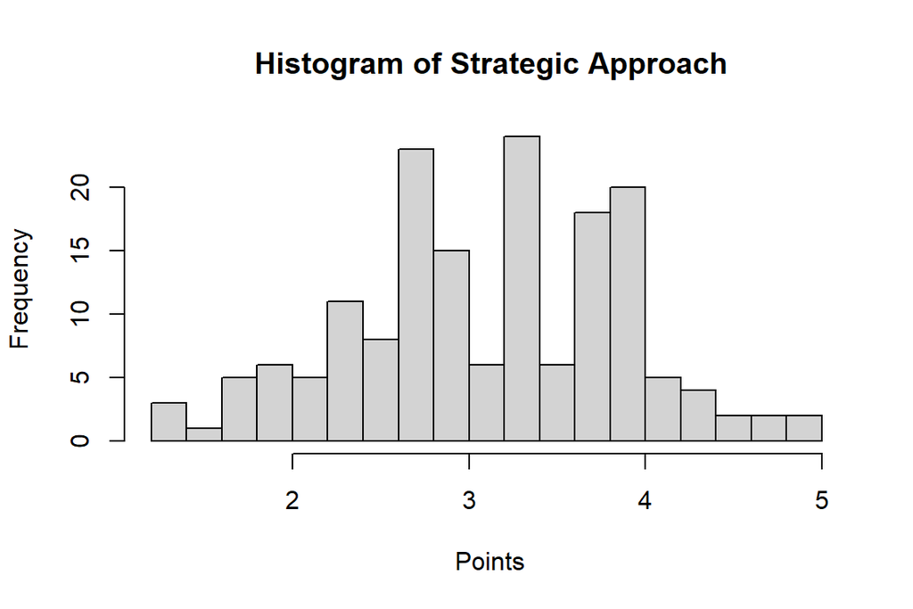

```r
hist(learning2014.data$stra,
breaks = 20,
xlab = " Points",
main = " Histogram of Strategic Approach")
```

From visual inspections, the distributions of the outcomes are near to normal distribution, except for total Points that are distributed more evenly.

The relationships between the outcomes of Surf, Stra and Deep, and Poits are presented in the following plots:

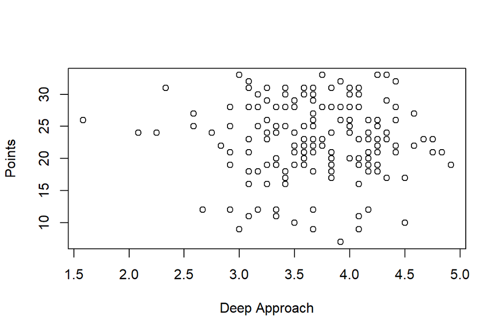

```r
plot(learning2014.data$deep, learning2014.data$points,
xlab = "Deep Approach",
ylab = "Points")
```

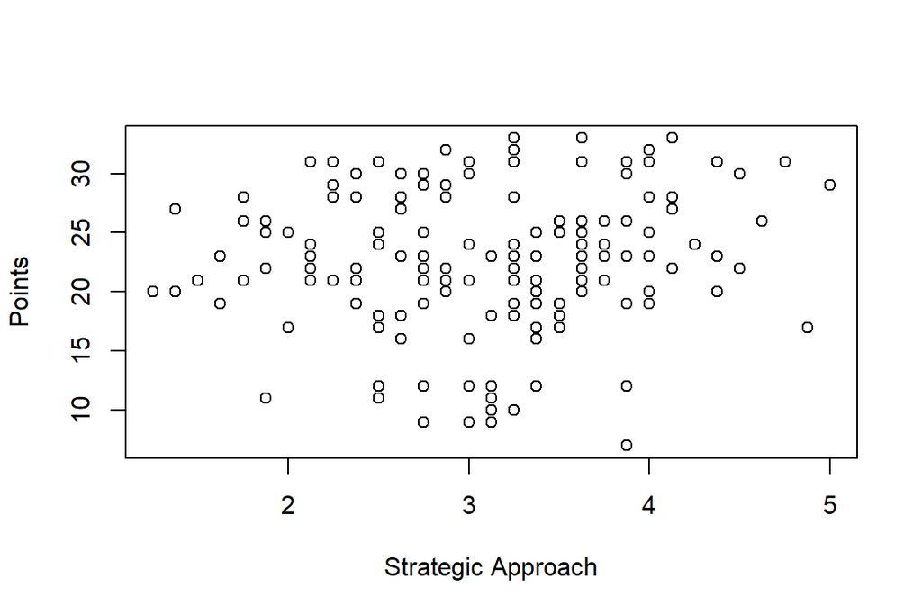

```r
plot(learning2014.data$stra, learning2014.data$points,
xlab = "Strategic Approach",
ylab = "Points")
```

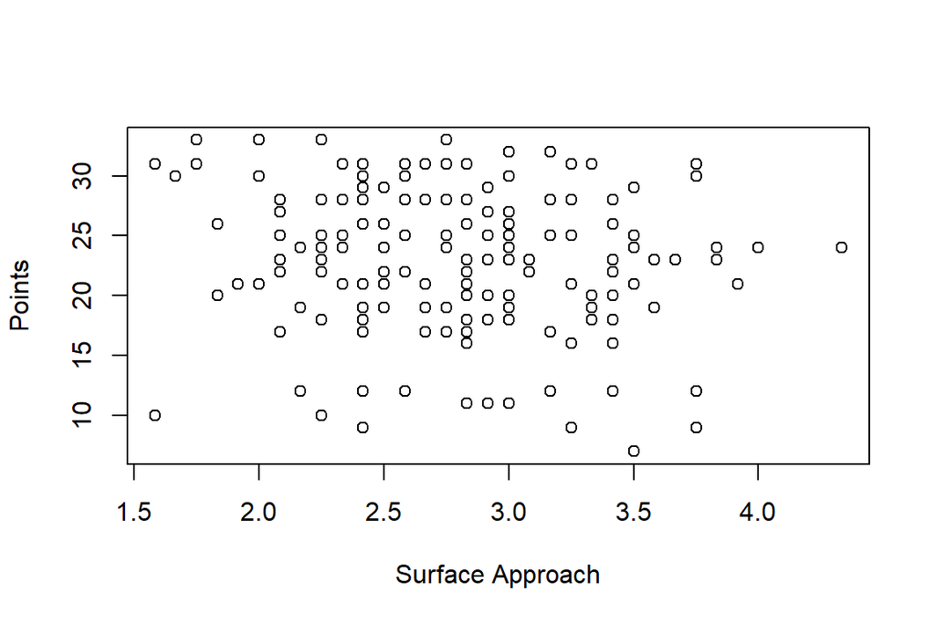

```r
plot(learning2014.data$surf, learning2014.data$points,
xlab = "Surface Approach",
ylab = "Points")
```

and here with the lines:

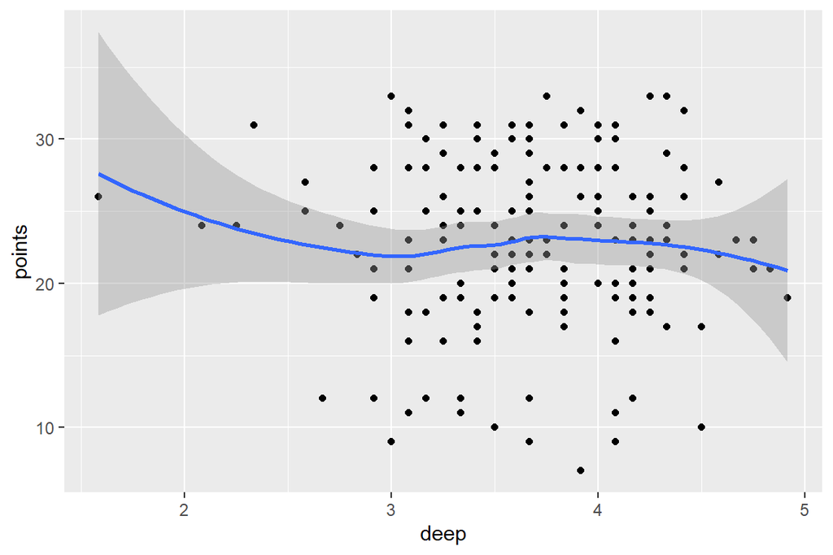

```r
ggplot(learning2014.data, aes(x = deep, y = points)) +
  geom_point() +
  stat_smooth()
```

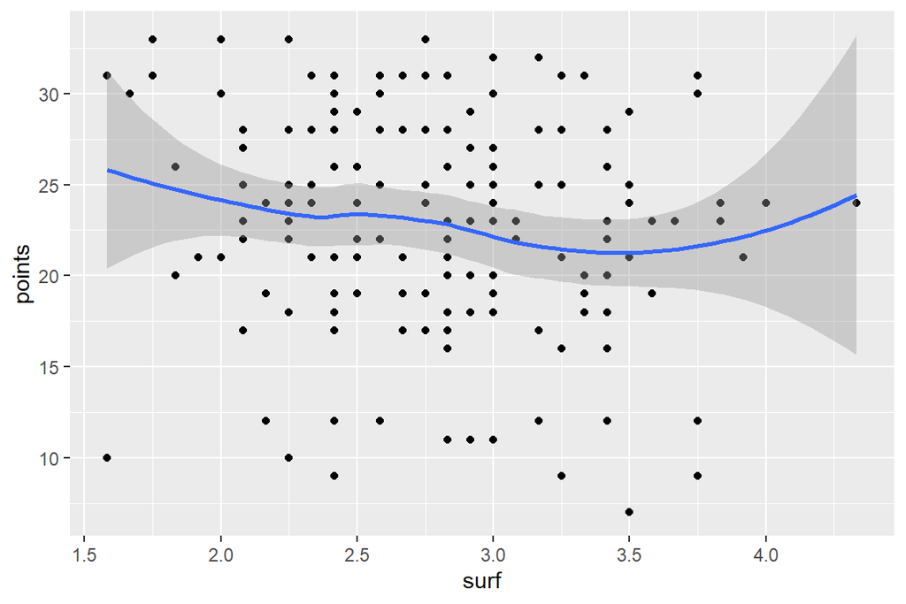

```r
ggplot(learning2014.data, aes(x = surf, y = points)) +
  geom_point() +
  stat_smooth()
```

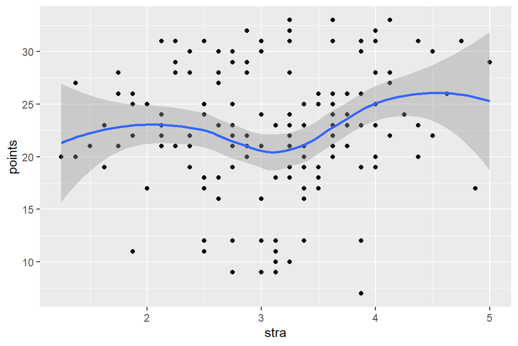

```r
ggplot(learning2014.data, aes(x = stra, y = points)) +
  geom_point() +
  stat_smooth()
```

Although the relationship between points and 3 outcomes is a bit less clear, it still appears somewhat linear. Linear regression can be proceed.

## 2.3 and 2.4. Regression analyses.

Model 1:

```r
#First the correlations are checked:

#check the correlations
#cor(learning2014.data$stra, learning2014.data$deep)
#cor(learning2014.data$stra, learning2014.data$surf)
#cor(learning2014.data$surf, learning2014.data$deep)
```

Linear regression model 1 with three variables (deep, stra, surf) as explanatory variables and exam points as the target (dependent, outcome) variable are summarized below:

```r
model1 <- lm(points ~ deep + stra + surf, data = learning2014.data)

summary(model1)
```

```
##
## Call:
## lm(formula = points ~ deep + stra + surf, data = learning2014.data)
##
## Residuals:
##      Min       1Q   Median       3Q      Max
## -15.1235  -3.0737   0.5226   4.2799  10.3229
##
## Coefficients:
##             Estimate Std. Error t value Pr(>|t|)
## (Intercept)  26.9143     5.1169   5.260  4.5e-07 ***
## deep         -0.7443     0.8662  -0.859   0.3915
## stra          0.9878     0.5962   1.657   0.0994 .
## surf         -1.6296     0.9153  -1.780   0.0769 .
## ---
## Signif. codes:  0 '***' 0.001 '**' 0.01 '*' 0.05 '.' 0.1 ' ' 1
##
## Residual standard error: 5.827 on 162 degrees of freedom
## Multiple R-squared:  0.04071,    Adjusted R-squared:  0.02295
## F-statistic: 2.292 on 3 and 162 DF,  p-value: 0.08016
```

The results show that the model is not statistically significant (F(3, 162) = 2.292, p = 0.08). The estimated effect of deep approach is -0.74 (p = 0.39), while the estimated effect for strategic approach is 0.99 (p = 0.10) and for surface approach -1.63 (0.08).

In the model1 2.3 % of the varince in the points can be predicted by the three outcomes.

Model2:

In the model 2, deep approach outcome is excluded from the model 1, and it is summarized here:

```r
model2 <- lm(points ~ stra + surf, data = learning2014.data)

summary(model2)
```

```
##
## Call:
## lm(formula = points ~ stra + surf, data = learning2014.data)
##
## Residuals:
##      Min       1Q   Median       3Q      Max
## -15.4574  -3.2820   0.4296   4.0737   9.8147
##
## Coefficients:
##             Estimate Std. Error t value Pr(>|t|)
## (Intercept)  23.5635     3.3104   7.118 3.31e-11 ***
## stra          0.9635     0.5950   1.619    0.107
## surf         -1.3828     0.8684  -1.592    0.113
## ---
## Signif. codes:  0 '***' 0.001 '**' 0.01 '*' 0.05 '.' 0.1 ' ' 1
##
## Residual standard error: 5.822 on 163 degrees of freedom
## Multiple R-squared:  0.03634,    Adjusted R-squared:  0.02452
## F-statistic: 3.074 on 2 and 163 DF,  p-value: 0.04895
```

The results depict that the model is now statistically significant (F(2, 163) = 3.074, p = 0.049). The estimated effect for strategic approach is 0.96 (p = 0.11) and for surface approach -1.38 (p = 0.11). This means that more strategic approach and less surface approach predicts the higher the points. However, even though the model is statistically significant, the the estimated effect are insignificant for independent variables.*

In the model2, 2.5 % of the variance in the points (adjusted R-squared) can be predicted by the two outcomes.

## 2.5. The diagnostic plots.

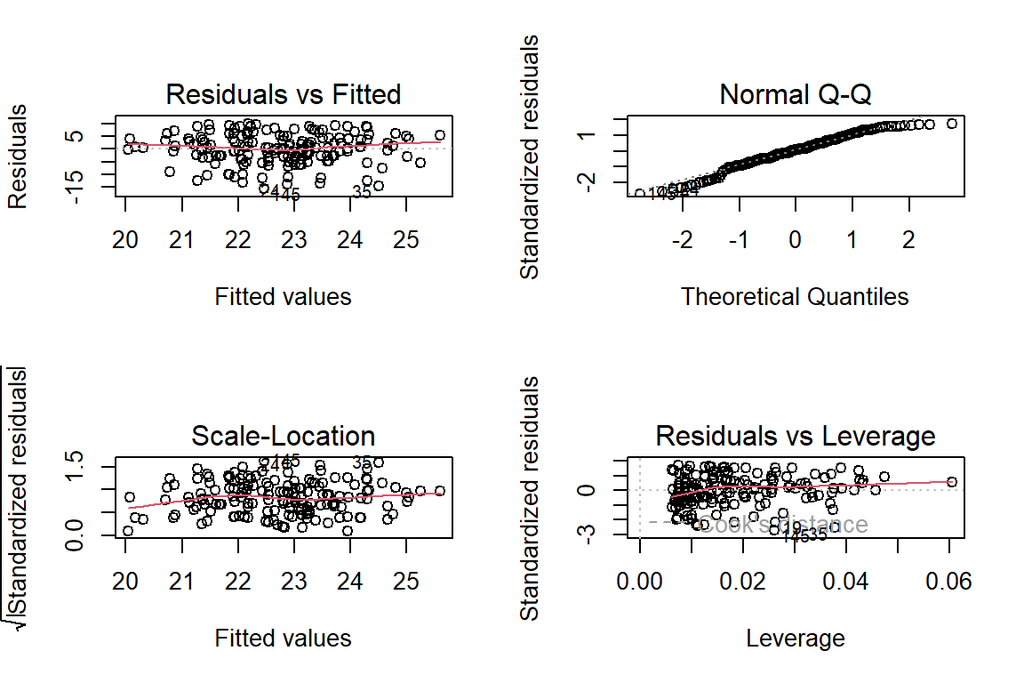

```r
par(mfrow=c(2,2))
plot(model2)
```

```r
par(mfrow=c(1,1))
```

There is the assumption of homoscedasticity in the model.

In a plot of residual vs fitted values red line represent the mean of the residuals. It supposed to be horizontal and centered around zero. This means there are no outliers or biases in the data that would make a linear regression invalid.In the model2, there are a little bias in small and large values of the points.

In the Normal Q-Qplot in the top right, you can see that the real residuals from model2 form an almost perfectly one-to-one line with the theoretical residuals from a perfect model when theoretical qouantiles are [-1, 1]

Based on these residuals, we can say that our model meets the assumption of homoscedasticity at least to a certain extent.

In the plot residuals vs leverage is shown several influential points that are below Cook’s distance. Leverage refers to the extent to which the coefficients in the regression model would change if a particular observation was removed from the dataset. Based on the results, there might be an option that another regression model would better fit in or the influential observations should be handle in another way.

# Assignment 3

```r
library(dplyr)

library(tidyverse)
#read the joined student alcohol consumption data into R from url (just in case that everything is correct)
library(readr)
alc <- read_csv("https://raw.githubusercontent.com/KimmoVehkalahti/Helsinki-Open-Data-Science/master/datasets/alc.csv", show_col_types=FALSE)

#print out the names of the variables in the data
colnames (alc)
```

```
##  [1] "school"     "sex"        "age"        "address"    "famsize"
##  [6] "Pstatus"    "Medu"       "Fedu"       "Mjob"       "Fjob"
## [11] "reason"     "guardian"   "traveltime" "studytime"  "schoolsup"
## [16] "famsup"     "activities" "nursery"    "higher"     "internet"
## [21] "romantic"   "famrel"     "freetime"   "goout"      "Dalc"
## [26] "Walc"       "health"     "failures"   "paid"       "absences"
## [31] "G1"         "G2"         "G3"         "alc_use"    "high_use"
```

```r
#N sex
alc %>% group_by(sex) %>% summarise(count = n())
```

```
## # A tibble: 2 × 2
##   sex   count
##   <chr> <int>
## 1 F       195
## 2 M       175
```

```r
#N age
alc %>% group_by(age) %>% summarise(count = n())
```

```
## # A tibble: 7 × 2
##     age count
##   <dbl> <int>
## 1    15    81
## 2    16   102
## 3    17    97
## 4    18    77
## 5    19    11
## 6    20     1
## 7    22     1
```

## 3.1 The description of the data

This data approach student achievement in secondary education of two Portuguese schools. The data attributes include student grades, demographic, social and school related features (35 variables) and it was collected by using school reports and questionnaires. Two data sets were first provided regarding the performance in two distinct subjects: Mathematics (mat) and Portuguese language (por). In this report I used a joined data set, where I made following adjustment: the grade variables were combined by averaging in math and Portuguese, ‘alc_use’ outcome was an average of workday alcohol consumption (numeric: from 1 - very low to 5 - very high) and weekend alcohol consumption (numeric: from 1 - very low to 5 - very high), and ‘hig_use’ outcome provide information if alc use was higher than 2. There were 370 participants in the study, of which 195 were females. Age range was from 15 to 22 years.

## 3.2 Personal hypothesis about the relationships of outcomes with alcohol consumption

I chose the variables of sex, final grade, number of school absences and current health status, to study their relationships to high/low alcohol consumption. My personal hypothesis were that 1) males have higher alcohol consumption than females, as well as 2) lower final grade, 3) higher number of school absences and 4) lower health status are predicted higher consumption.

## 3.3 The distribuiton of the chosen variables and their relationships with alcohol consumption

```r
#sex
#high use as another grouping variable
alc %>% group_by(sex, high_use) %>% summarise(count = n())
```

[output not shown]

```
## # A tibble: 4 × 3
## # Groups:   sex [2]
##   sex   high_use count
##   <chr> <lgl>    <int>
## 1 F     FALSE      154
## 2 F     TRUE        41
## 3 M     FALSE      105
## 4 M     TRUE        70
```

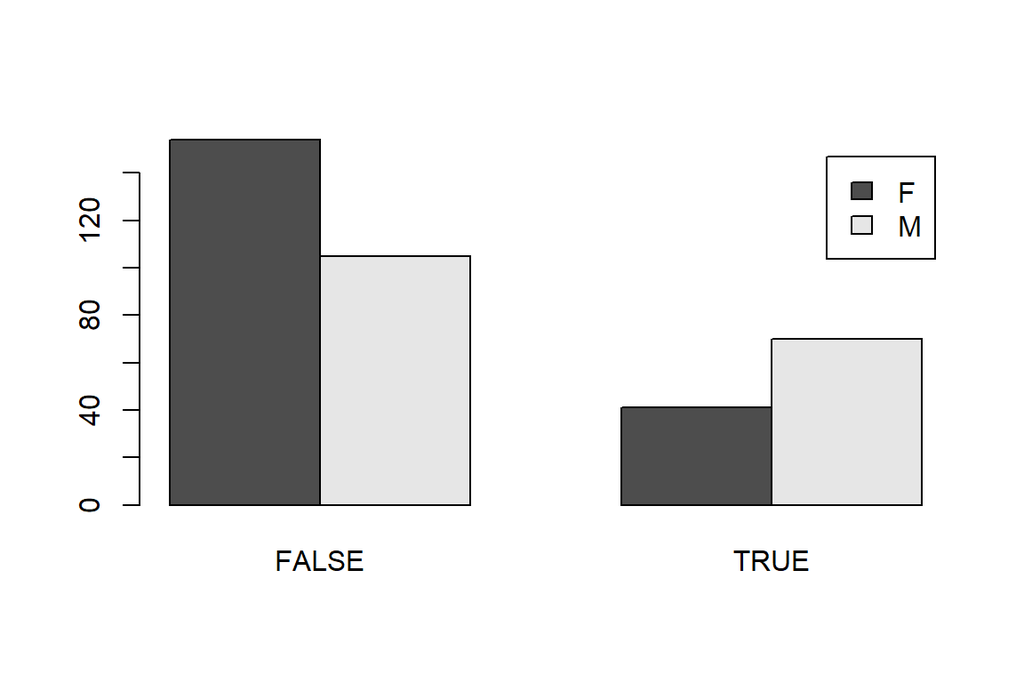

```r
# draw a bar plot of high_use by sex
attach(alc)
counts <- table(sex, high_use)
 barplot(counts,beside=T,legend=c('F','M'))
```

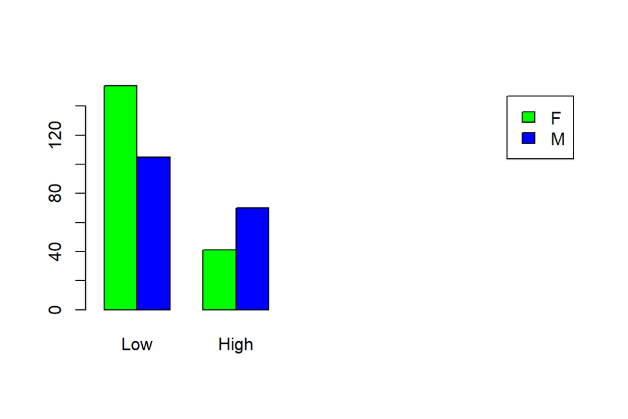

```r
 barplot(counts,col=c('green','blue'),
         names.arg=c('Low', 'High'),
       beside=T,legend=c('F','M'), xlim=c(1,15))
```

By sex, males have more often high alcohol consumption than females (Male N = 70, Female N = 41). This relationship is illustrated in Barplot.

```r
#final grade

#means of the grades of the student
alc %>% group_by(high_use) %>% summarise(mean_grade = mean(G3))
```

```
## # A tibble: 2 × 2
##   high_use mean_grade
##   <lgl>         <dbl>
## 1 FALSE          11.8
## 2 TRUE           10.9
```

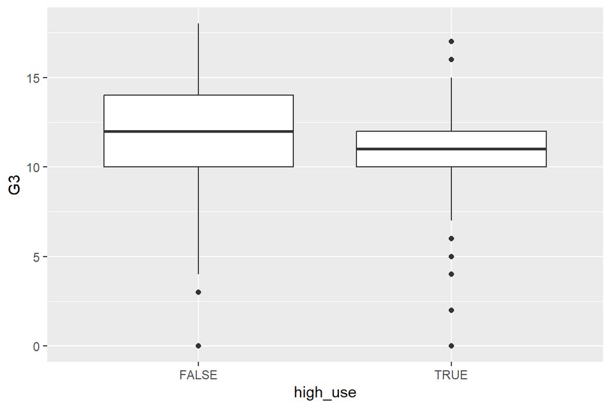

```r
#boxplot
alc %>% ggplot(aes(x = high_use, y = G3)) +
  geom_boxplot()
```

```r
#means of the grades of the student by gender
alc %>% group_by(sex, high_use) %>% summarise(mean_grade = mean(G3))
```

[output not shown]

```
## # A tibble: 4 × 3
## # Groups:   sex [2]
##   sex   high_use mean_grade
##   <chr> <lgl>         <dbl>
## 1 F     FALSE          11.4
## 2 F     TRUE           11.8
## 3 M     FALSE          12.3
## 4 M     TRUE           10.3
```

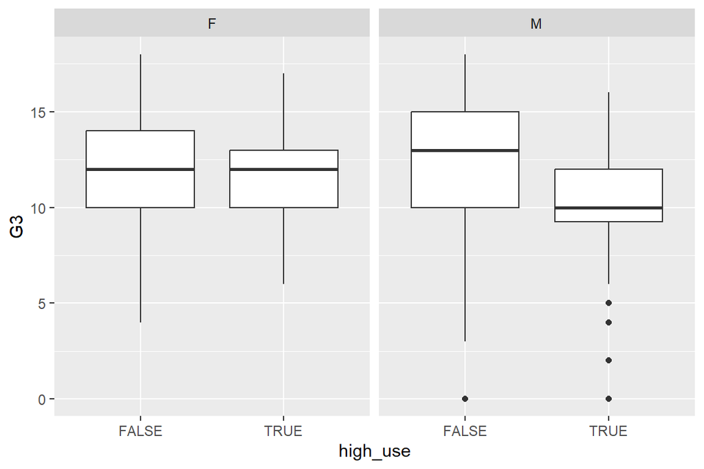

```r
plot1 = ggplot(alc, aes(x=high_use, y=G3)) + geom_boxplot() + facet_grid(~sex)
plot1
```

The descriptive statistics by grade show that mean of grade is higher in low alcohol consumption group (11.80 vs 10.86). The mean grades varied by gender; so that in males the differences in means was larger between the high and low consumption groups as compared to females. These results are illustrated in boxplots above.

```r
#school absences

#means of the absences of the student
alc %>% group_by(high_use) %>% summarise(mean_absences = mean(absences))
```

```
## # A tibble: 2 × 2
##   high_use mean_absences
##   <lgl>            <dbl>
## 1 FALSE             3.71
## 2 TRUE              6.38
```

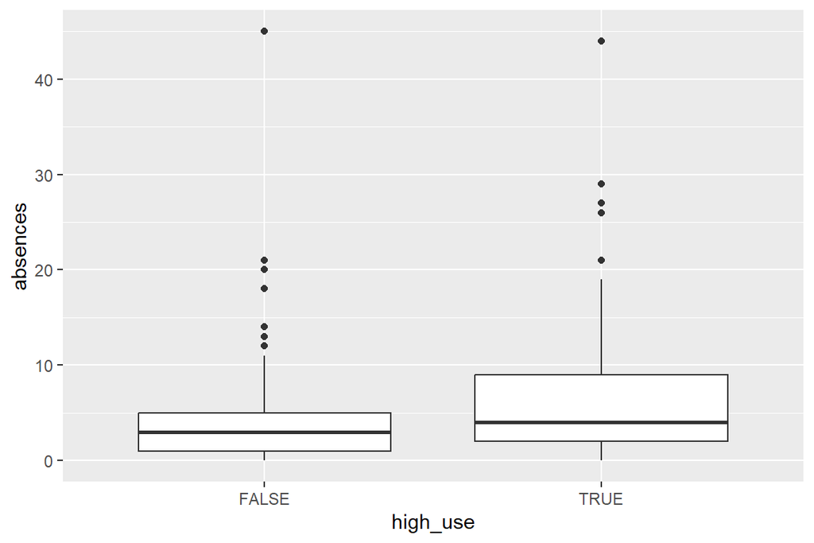

```r
#boxplot
alc %>% ggplot(aes(x = high_use, y = absences)) +
  geom_boxplot()
```

```r
#means of absences of the student by gender
alc %>% group_by(sex, high_use) %>% summarise(mean_grade = mean(absences))
```

[output not shown]

```
## # A tibble: 4 × 3
## # Groups:   sex [2]
##   sex   high_use mean_grade
##   <chr> <lgl>         <dbl>
## 1 F     FALSE          4.25
## 2 F     TRUE           6.85
## 3 M     FALSE          2.91
## 4 M     TRUE           6.1
```

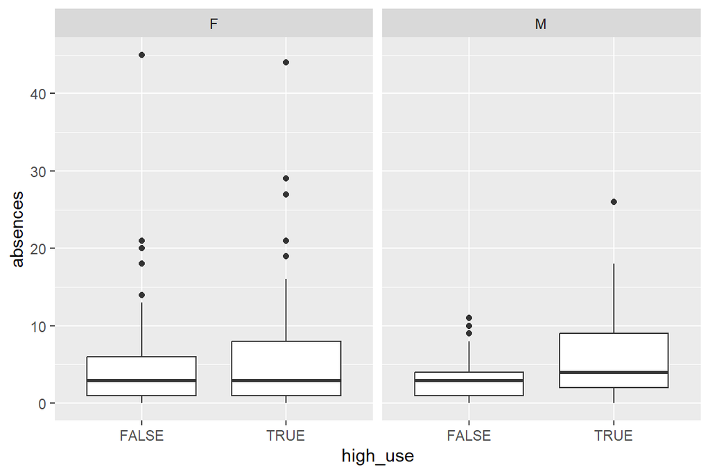

```r
plot2 = ggplot(alc, aes(x=high_use, y=absences)) + geom_boxplot() + facet_grid(~sex)
plot2
```

By school absences, more absences were found in high use group (means: 6.37 vs 3.71). In males the mean difference of school absences was larger between the low and high alcohol consumption groups than in females. However, females with high consumption had more absences than males with high consumption.

```r
#health

#means of current health status of the student
alc %>% group_by(high_use) %>% summarise(mean_health = mean(health))
```

```
## # A tibble: 2 × 2
##   high_use mean_health
##   <lgl>          <dbl>
## 1 FALSE           3.49
## 2 TRUE            3.73
```

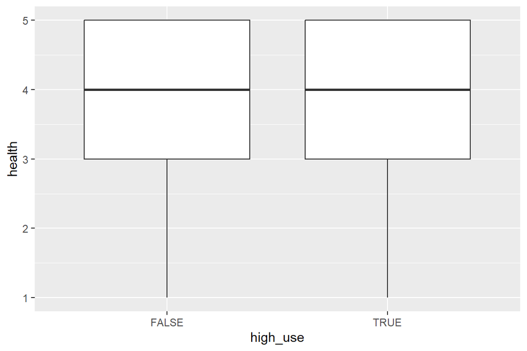

```r
#boxplot
alc %>% ggplot(aes(x = high_use, y = health)) +
  geom_boxplot()
```

```r
#means of health status of the student by gender
alc %>% group_by(sex, high_use) %>% summarise(mean_health = mean(health))
```

[output not shown]

```
## # A tibble: 4 × 3
## # Groups:   sex [2]
##   sex   high_use mean_health
##   <chr> <lgl>          <dbl>
## 1 F     FALSE           3.37
## 2 F     TRUE            3.39
## 3 M     FALSE           3.67
## 4 M     TRUE            3.93
```

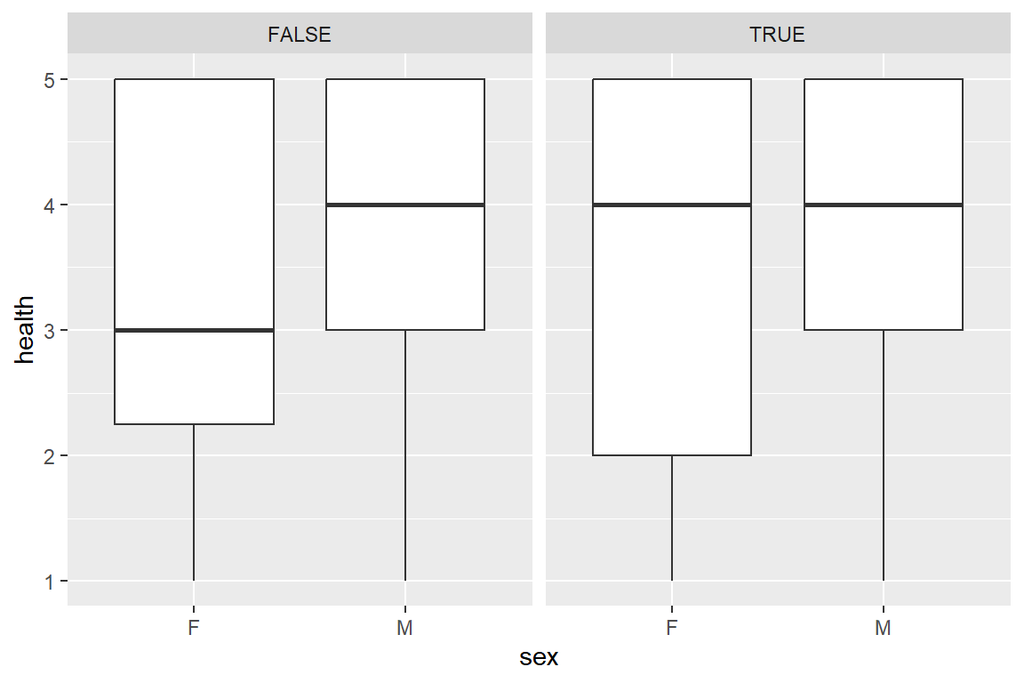

```r
plot3 = ggplot(alc, aes(x=sex, y=health)) + geom_boxplot() + facet_grid(~high_use)
plot3
```

## 3.4 Logistic regression

```r
#model1

# find the model with glm()
model1 <- glm(high_use ~ G3 + absences + sex + health, data = alc, family = "binomial")

# print out a summary of the model
summary(model1)
```

```
##
## Call:
## glm(formula = high_use ~ G3 + absences + sex + health, family = "binomial",
##     data = alc)
##
## Deviance Residuals:
##     Min       1Q   Median       3Q      Max
## -2.2867  -0.8513  -0.6097   1.0669   2.1530
##
## Coefficients:
##             Estimate Std. Error z value Pr(>|z|)
## (Intercept) -1.20679    0.58419  -2.066   0.0389 *
## G3          -0.07619    0.03680  -2.070   0.0384 *
## absences     0.09262    0.02333   3.970 7.19e-05 ***
## sexM         1.02053    0.24766   4.121 3.78e-05 ***
## health       0.06783    0.08880   0.764   0.4450
## ---
## Signif. codes:  0 '***' 0.001 '**' 0.01 '*' 0.05 '.' 0.1 ' ' 1
##
## (Dispersion parameter for binomial family taken to be 1)
##
##     Null deviance: 452.04  on 369  degrees of freedom
## Residual deviance: 410.38  on 365  degrees of freedom
## AIC: 420.38
##
## Number of Fisher Scoring iterations: 4
```

```r
# print out the coefficients of the model
matrix_coef <- summary(model1)$coefficients
matrix_coef
```

```
##                Estimate Std. Error    z value     Pr(>|z|)
## (Intercept) -1.20678611 0.58419346 -2.0657303 3.885396e-02
## G3          -0.07619428 0.03680458 -2.0702387 3.842999e-02
## absences     0.09262464 0.02333255  3.9697599 7.194508e-05
## sexM         1.02053470 0.24766087  4.1206942 3.777325e-05
## health       0.06782637 0.08880294  0.7637853 4.449952e-01
```

```r
# compute odds ratios (OR)
OR1 <- coef(model1) %>% exp

# compute confidence intervals (CI)
CI1 <- confint(model1) %>% exp()
# print out the odds ratios with their confidence intervals
cbind(OR1, CI1)
```

```
##                   OR1      2.5 %    97.5 %
## (Intercept) 0.2991572 0.09342207 0.9282541
## G3          0.9266362 0.86143669 0.9956498
## absences    1.0970499 1.05023715 1.1509892
## sexM        2.7746780 1.71811644 4.5452414
## health      1.0701795 0.90040767 1.2764711
```

```r
model2 <- glm(high_use ~ G3 + absences + health + sex -1, data = alc, family = "binomial")

# print out a summary of the model
summary(model2) #no intercept model
```

```
##
## Call:
## glm(formula = high_use ~ G3 + absences + health + sex - 1, family = "binomial",
##     data = alc)
##
## Deviance Residuals:
##     Min       1Q   Median       3Q      Max
## -2.2867  -0.8513  -0.6097   1.0669   2.1530
##
## Coefficients:
##          Estimate Std. Error z value Pr(>|z|)
## G3       -0.07619    0.03680  -2.070   0.0384 *
## absences  0.09262    0.02333   3.970 7.19e-05 ***
## health    0.06783    0.08880   0.764   0.4450
## sexF     -1.20679    0.58419  -2.066   0.0389 *
## sexM     -0.18625    0.59610  -0.312   0.7547
## ---
## Signif. codes:  0 '***' 0.001 '**' 0.01 '*' 0.05 '.' 0.1 ' ' 1
##
## (Dispersion parameter for binomial family taken to be 1)
##
##     Null deviance: 512.93  on 370  degrees of freedom
## Residual deviance: 410.38  on 365  degrees of freedom
## AIC: 420.38
##
## Number of Fisher Scoring iterations: 4
```

```r
matrix_coef2 <- summary(model2)$coefficients
matrix_coef2
```

```
##             Estimate Std. Error    z value     Pr(>|z|)
## G3       -0.07619428 0.03680458 -2.0702387 3.842999e-02
## absences  0.09262464 0.02333255  3.9697599 7.194508e-05
## health    0.06782637 0.08880294  0.7637853 4.449952e-01
## sexF     -1.20678611 0.58419346 -2.0657303 3.885396e-02
## sexM     -0.18625141 0.59609939 -0.3124503 7.546984e-01
```

```r
# compute odds ratios (OR)
OR2 <- coef(model2) %>% exp

# compute confidence intervals (CI)
CI2 <- confint(model2) %>% exp()
# print out the odds ratios with their confidence intervals
cbind(OR2, CI2)
```

```
##                OR2      2.5 %    97.5 %
## G3       0.9266362 0.86143669 0.9956498
## absences 1.0970499 1.05023715 1.1509892
## health   1.0701795 0.90040767 1.2764711
## sexF     0.2991572 0.09342207 0.9282541
## sexM     0.8300649 0.25579031 2.6667851
```

## 3.5 Predictive power of the model

```r
library(readr)
library(dplyr)
library(boot)
```

```r
library(ggplot2)

# fit the model with outcomes of statistically significant relationships
model1 <- glm(high_use ~ G3 + absences + sex, data = alc, family = "binomial")

# predict() the probability of high_use
probabilities <- predict(model1, type = "response")

library(dplyr)
# add the predicted probabilities to 'alc'
alc <- mutate(alc, probability = probabilities)

# use the probabilities to make a prediction of high_use
alc <- mutate(alc, prediction = probability > 0.5)


# tabulate the target variable versus the predictions
table(high_use = alc$high_use, prediction = alc$prediction)
```

```
##         prediction
## high_use FALSE TRUE
##    FALSE   248   11
##    TRUE     83   28
```

```r
#table for probabilities
table(high_use = alc$high_use, prediction = alc$prediction) %>% prop.table()
```

```
##         prediction
## high_use      FALSE       TRUE
##    FALSE 0.67027027 0.02972973
##    TRUE  0.22432432 0.07567568
```

```r
#add margins
table(high_use = alc$high_use, prediction = alc$prediction) %>% prop.table() %>% addmargins()
```

```
##         prediction
## high_use      FALSE       TRUE        Sum
##    FALSE 0.67027027 0.02972973 0.70000000
##    TRUE  0.22432432 0.07567568 0.30000000
##    Sum   0.89459459 0.10540541 1.00000000
```

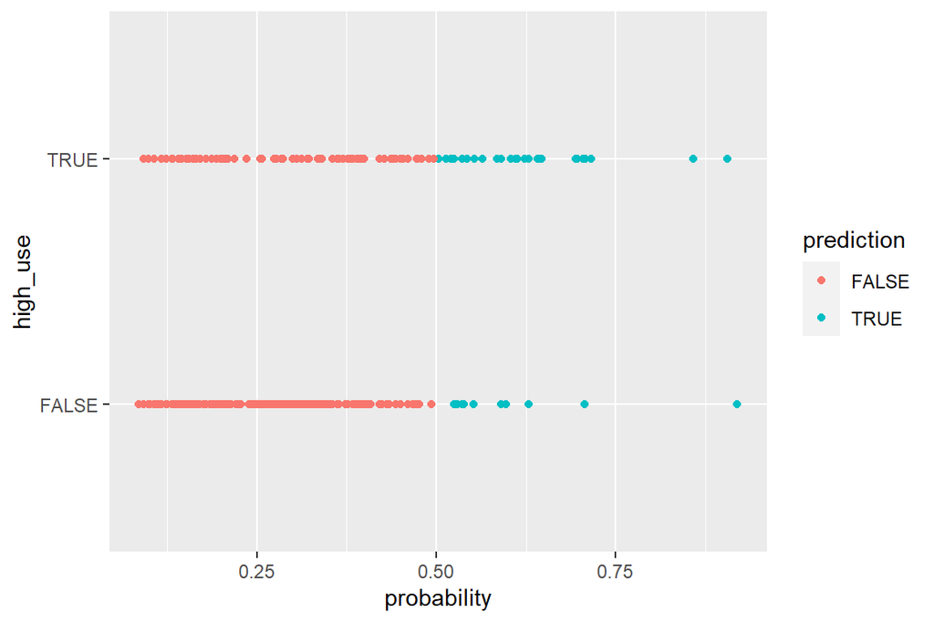

```r
#plot
library(ggplot2)
g2 <- ggplot(alc, aes(x = probability, y = high_use, col = prediction))
g2 + geom_point()
```

```r
# define a loss function (average prediction error)
loss_func <- function(class, prob) {
  n_wrong <- abs(class - prob) > 0.5
  mean(n_wrong)
}

# call loss_func to compute the average number of wrong predictions in the (training) data
loss_func(class = alc$high_use, prob = alc$probability)
```

```
## [1] 0.2540541
```

The total proportion of inaccurately classified individual i.e., the training error is 0.25 for the model. Performance of the the model is similar than simple guessing strategy.

# Assignment 4

```r
# access the MASS package
library(MASS)
# load the data
data("Boston")

# explore the dataset
str(Boston)
```

```
## 'data.frame':    506 obs. of  14 variables:
##  $ crim   : num  0.00632 0.02731 0.02729 0.03237 0.06905 ...
##  $ zn     : num  18 0 0 0 0 0 12.5 12.5 12.5 12.5 ...
##  $ indus  : num  2.31 7.07 7.07 2.18 2.18 2.18 7.87 7.87 7.87 7.87 ...
##  $ chas   : int  0 0 0 0 0 0 0 0 0 0 ...
##  $ nox    : num  0.538 0.469 0.469 0.458 0.458 0.458 0.524 0.524 0.524 0.524 ...
##  $ rm     : num  6.58 6.42 7.18 7 7.15 ...
##  $ age    : num  65.2 78.9 61.1 45.8 54.2 58.7 66.6 96.1 100 85.9 ...
##  $ dis    : num  4.09 4.97 4.97 6.06 6.06 ...
##  $ rad    : int  1 2 2 3 3 3 5 5 5 5 ...
##  $ tax    : num  296 242 242 222 222 222 311 311 311 311 ...
##  $ ptratio: num  15.3 17.8 17.8 18.7 18.7 18.7 15.2 15.2 15.2 15.2 ...
##  $ black  : num  397 397 393 395 397 ...
##  $ lstat  : num  4.98 9.14 4.03 2.94 5.33 ...
##  $ medv   : num  24 21.6 34.7 33.4 36.2 28.7 22.9 27.1 16.5 18.9 ...
```

## 4.1 The description of Boston data

The Boston data frame has 506 rows and 14 columns. The columns are following:

crim: per capita crime rate by town. zn: proportion of residential land zoned for lots over 25,000 sq.ft. indus: proportion of non-retail business acres per town. chas: Charles River dummy variable (= 1 if tract bounds river; 0 otherwise). nox: nitrogen oxides concentration (parts per 10 million). rm: average number of rooms per dwelling. age: proportion of owner-occupied units built prior to 1940. dis: weighted mean of distances to five Boston employment centres. rad: index of accessibility to radial highways. tax: full-value property-tax rate per $10,000. ptratio: pupil-teacher ratio by town. black: 1000(Bk - 0.63)^2, where Bk is the proportion of blacks by town. lstat: lower status of the population (percent). medv: median value of owner-occupied homes in $1000s.

## 4.2 An overview and summary of the data

```r
library(MASS)
library(tidyr)
library(corrplot)
library(ggplot2)
#summary of the data
colnames (Boston)
```

```
##  [1] "crim"    "zn"      "indus"   "chas"    "nox"     "rm"      "age"
##  [8] "dis"     "rad"     "tax"     "ptratio" "black"   "lstat"   "medv"
```

```r
summary(Boston)
```

```
##       crim                zn             indus            chas
##  Min.   : 0.00632   Min.   :  0.00   Min.   : 0.46   Min.   :0.00000
##  1st Qu.: 0.08205   1st Qu.:  0.00   1st Qu.: 5.19   1st Qu.:0.00000
##  Median : 0.25651   Median :  0.00   Median : 9.69   Median :0.00000
##  Mean   : 3.61352   Mean   : 11.36   Mean   :11.14   Mean   :0.06917
##  3rd Qu.: 3.67708   3rd Qu.: 12.50   3rd Qu.:18.10   3rd Qu.:0.00000
##  Max.   :88.97620   Max.   :100.00   Max.   :27.74   Max.   :1.00000
##       nox               rm             age              dis
##  Min.   :0.3850   Min.   :3.561   Min.   :  2.90   Min.   : 1.130
##  1st Qu.:0.4490   1st Qu.:5.886   1st Qu.: 45.02   1st Qu.: 2.100
##  Median :0.5380   Median :6.208   Median : 77.50   Median : 3.207
##  Mean   :0.5547   Mean   :6.285   Mean   : 68.57   Mean   : 3.795
##  3rd Qu.:0.6240   3rd Qu.:6.623   3rd Qu.: 94.08   3rd Qu.: 5.188
##  Max.   :0.8710   Max.   :8.780   Max.   :100.00   Max.   :12.127
##       rad              tax           ptratio          black
##  Min.   : 1.000   Min.   :187.0   Min.   :12.60   Min.   :  0.32
##  1st Qu.: 4.000   1st Qu.:279.0   1st Qu.:17.40   1st Qu.:375.38
##  Median : 5.000   Median :330.0   Median :19.05   Median :391.44
##  Mean   : 9.549   Mean   :408.2   Mean   :18.46   Mean   :356.67
##  3rd Qu.:24.000   3rd Qu.:666.0   3rd Qu.:20.20   3rd Qu.:396.23
##  Max.   :24.000   Max.   :711.0   Max.   :22.00   Max.   :396.90
##      lstat            medv
##  Min.   : 1.73   Min.   : 5.00
##  1st Qu.: 6.95   1st Qu.:17.02
##  Median :11.36   Median :21.20
##  Mean   :12.65   Mean   :22.53
##  3rd Qu.:16.95   3rd Qu.:25.00
##  Max.   :37.97   Max.   :50.00
```

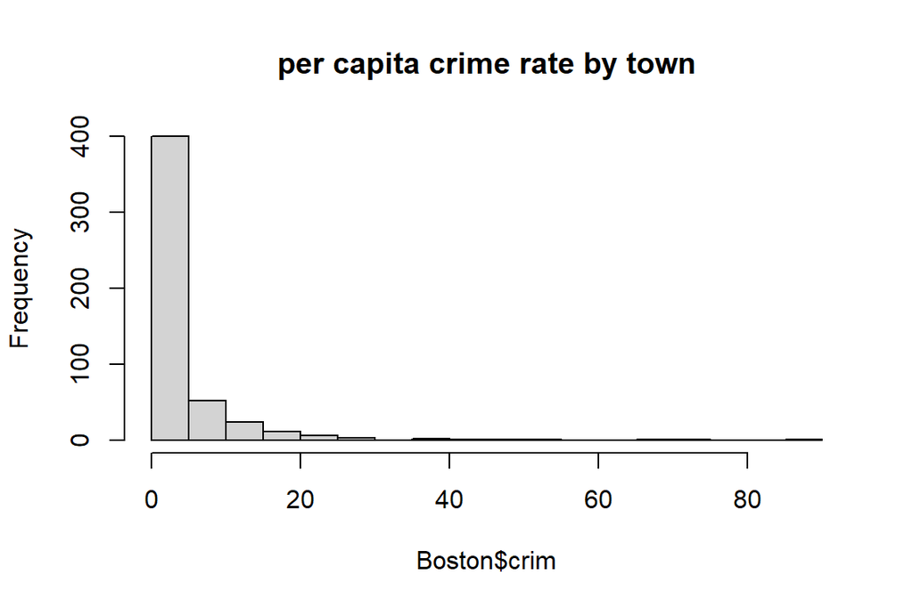

```r
# Histograms
hist(Boston$crim, main = "per capita crime rate by town", breaks = 30)
```

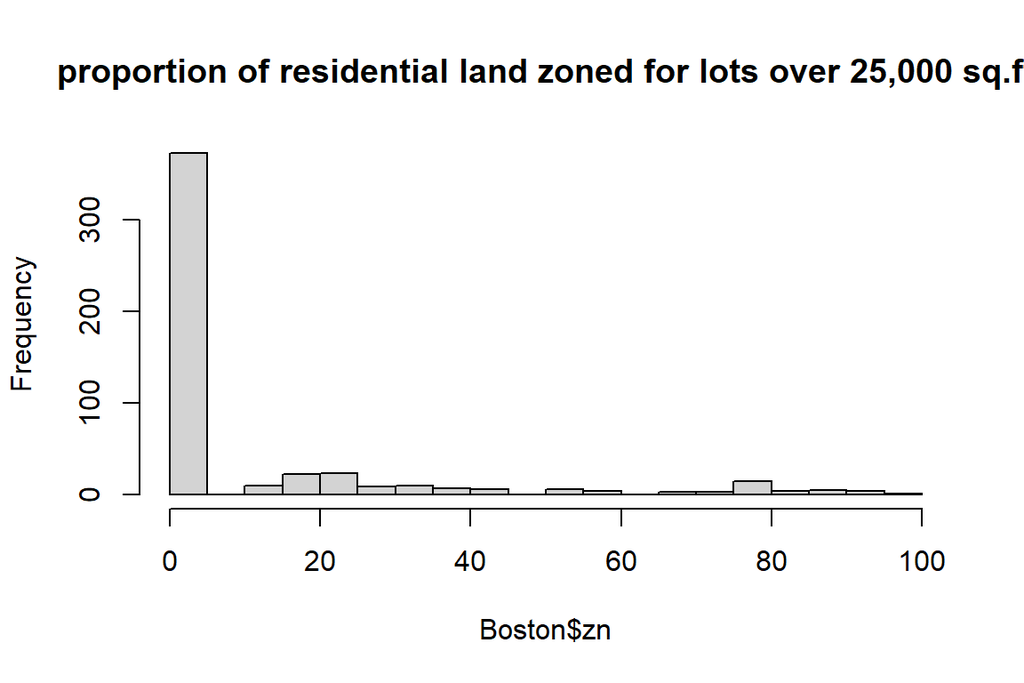

```r
hist(Boston$zn, main = "proportion of residential land zoned for lots over 25,000 sq.ft", breaks = 30)
```

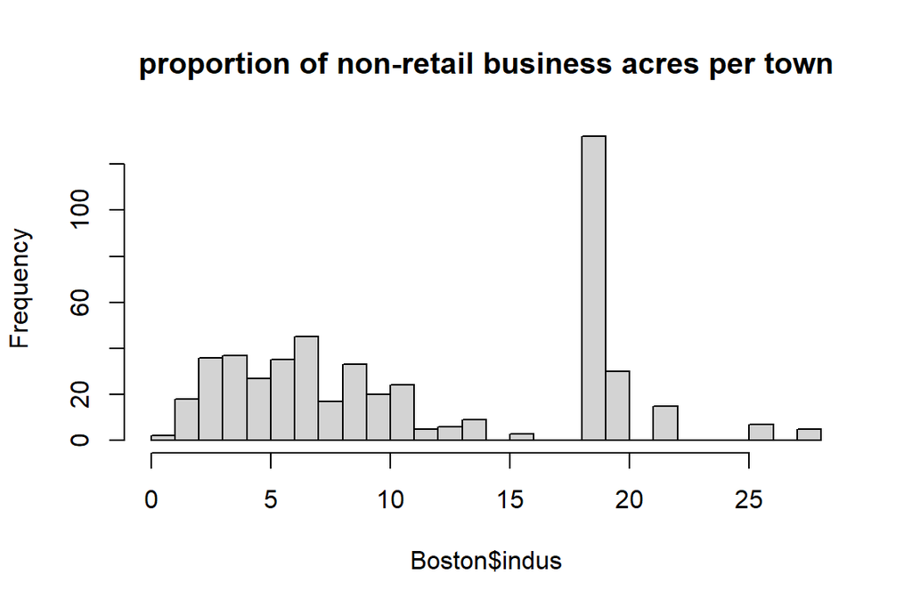

```r
hist(Boston$indus, main = "proportion of non-retail business acres per town", breaks = 30)
```

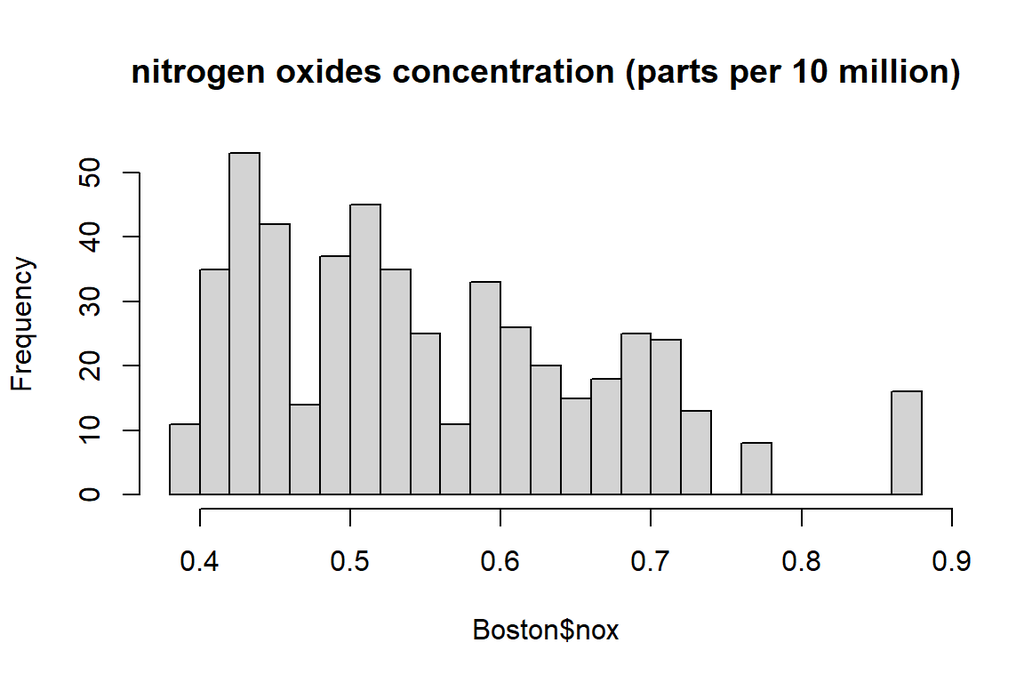

```r
hist(Boston$nox, main = "nitrogen oxides concentration (parts per 10 million)", breaks = 30)
```

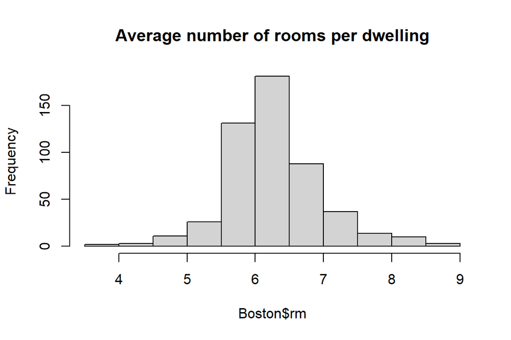

```r
hist(Boston$rm, main = "Average number of rooms per dwelling", breaks = 15)
```

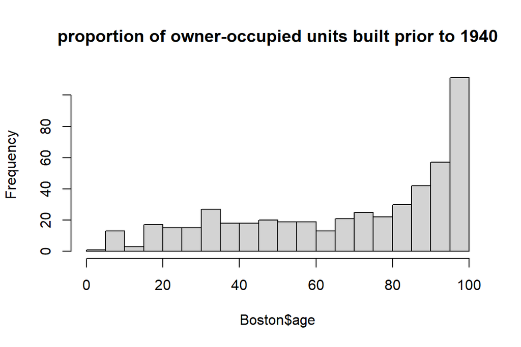

```r
hist(Boston$age, main = "proportion of owner-occupied units built prior to 1940", breaks = 30)
```

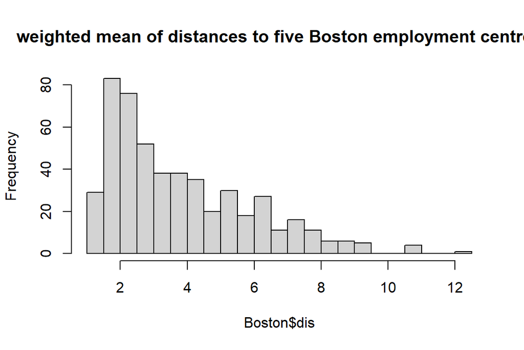

```r
hist(Boston$dis, main = "weighted mean of distances to five Boston employment centres", breaks = 30)
```

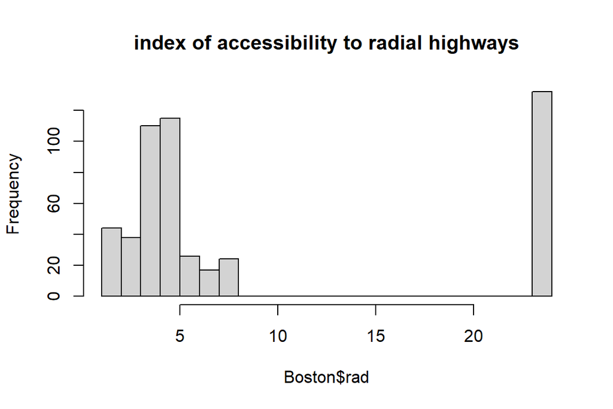

```r
hist(Boston$rad, main = "index of accessibility to radial highways", breaks =30)
```